# Class 4 Assignment - HTML development inside and outside CARTO

NINT5423 | Fall 2023

## Concepts & Themes:

This week’s assignment will encompass the following concepts, some of which will be previewed during the **Class 4**:

- HTML Syntax for web pages [`index.html`]
- HTML CARTO Syntax for *pop-up* mapping components

## Class 4 Links:

- [Agenda](https://gis-nspe-tns.github.io/GIS_NINT5423_spring_2023/agendas/c4_agenda_spring_23_NINT5423.html)
- [Lecture 4](https://gis-nspe-tns.github.io/GIS_NINT5423_spring_2023/lectures/lecture.4/index.html)
- [Assignment 4 (This Document)](https://gis-nspe-tns.github.io/GIS_NINT5423_spring_2023/assignments/c4_assignment_spring_23_NINT5423.html)
- [Lecture Demonstration](https://gis-nspe-tns.github.io/GIS_NINT5423_spring_2023/demos/c4.lecture.demo.html)
- [Class 4 Demonstration Code](https://github.com/gis-nspe-tns/GIS_NINT5423_spring_2023/blob/master/demo_code/c4_html-starter.html)
- [Class 4 HTML for CARTO pop-ups and legends video tutorial](https://github.com/gis-nspe-tns/GIS_NINT5423_spring_2023/blob/master/demo_code/class-4-video-html-examples.html)
- [Class 4 Lecture Demo Data](https://www.dropbox.com/s/8l3wlvtmhylb616/c4_inclass-data.zip?dl=1)

### Class 4 CARTO HTML for pop-ups and legends Video Guide:

- [CARTO HTML Video Tutorial/Guide](https://vimeo.com/753645469)

### HTML Reference Links + PDFs:

- [HTML Cheatsheet](https://gis-nint4523.s3.us-east-2.amazonaws.com/pdf-materials/html_cheatsheet.pdf)
- [Marksheet HTML Tutorial](https://marksheet.io/)
- [internetingishard HTML Tutorial](https://www.internetingishard.com/)

> Note: [Marksheet HTML Tutorial](https://marksheet.io/) and [internetingishard HTML Tutorial](https://www.internetingishard.com/) are comprehensive online guides/tutorials for getting started with HTML. Both are good, concise additions to this week’s lecture and inclass demostration labs.

## CARTO HTML for maps (Part #1):

- This week’s assignment will consist of two parts. Part #1 features working with HTML syntax *within* CARTO map[s]. Both legend and pop-up map elements can be modified extensively to tailor the performance of a CARTO map. Utilize the following video guide to orient towards effective revision/modification of both map elements - legends and pop-ups:

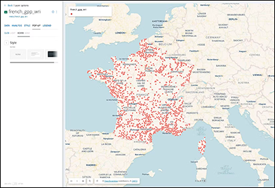

- To start, navigate to your CARTO account and either develop a new map based on skills/procedures you’ve learned in the previous 3 classes; or alter an existing map created in CARTO in previous classes.
- Next, edit the legend to add a link (or links) to your datasource(s) utilized in the map. Utilize the [Class 4 HTML for CARTO pop-ups and legends video tutorial](https://vimeo.com/753645469) for legend revisions.
- Following the legend edit[s], Make a change to the HTML for the pop-ups for your map. This can be as simple as adding `<strong>` elements to emphasize some text, or you could link to other pages or show images. Again, utilize [Class 4 HTML for CARTO pop-ups and legends video tutorial](https://vimeo.com/753645469) for pop-up revisions.

## HTML page development (Part #2)

- In this second assignment component, you will reference your CARTO map from Part #1 above utilizing the `embed` `iframe` element approach covered in [Lecture 4 Demonstration](https://gis-nspe-tns.github.io/GIS_NINT5423_spring_2023/demos/c4.lecture.demo.html).
- To start, navigate to your [Glitch](https://glitch.com/) account and initiate a new `hello-website`:

[figure not shown]

Initiate new `hello-website`

- Next, either revise the default `hello-website > index.html`, or clear the html code therein and start with a ‘blank slate’ using a standard HTML template (HTML5 Template), one of which is available as [Class 4 Demonstration Code](https://gis-nspe-tns.github.io/GIS_NINT5423_spring_2023/demo_code/c4_html-starter.html):

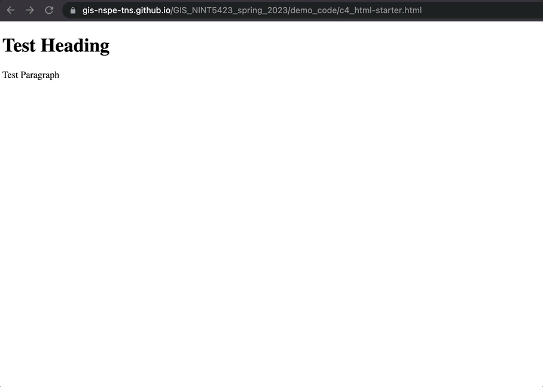

Access code via `View Page Source` from [Class 4 Demonstration Code](https://gis-nspe-tns.github.io/GIS_NINT5423_spring_2023/demo_code/c4_html-starter.html)

> Note: if you would like to do your HTML development in your destkop editor (VS Code), that is a valid/encouraged option. Once you complete your development, you can then simply `copy > paste` to your Glitch `hello-website > index.html`. Keep in mind that Glitch logs ‘project hours’ of which there is a limit per month in the free tier. Make sure to close your browser to the site when you are not actively working in Glitch to keep your ‘project hours’ to a minimum.
- In your HTML `index.html` development, include *at least* the following additions/revisions:
1. Embed the Carto map from Part 1 in the page as an `iframe`
2. Add a Title to the page
3. Add a short synopsis of your `iframe` map
4. Add at least one image
5. Add at least one link
- Remember to access the [HTML Cheatsheet](https://gis-nint4523.s3.us-east-2.amazonaws.com/pdf-materials/html_cheatsheet.pdf) to assist your HTML development for the 5 page components noted above, as well as any further development that you chose to do.
- If you are working primarily in Glitch, remember to format your final html. You can do this step via the *Prettier* tab at the top of your html document:

[figure not shown]

Glitch offers a built-in code formatting tool

## Assignment 4 deliverable (Part #3):

- After completion of Part #1 and #2 above, prepare a 1 page `PDF` synopsis of your work including the following:
1. A synopsis paragraph or two describing your assignment 4 development both in the CARTO map and in the Glitch HTML page.
2. A valid link to the CARTO map itself. This is the link option following `Publish` titled **Get the link** (left side).
3. Valid links to the Glitch project developed in Part #2 - both the `code` link and the `live site` links.

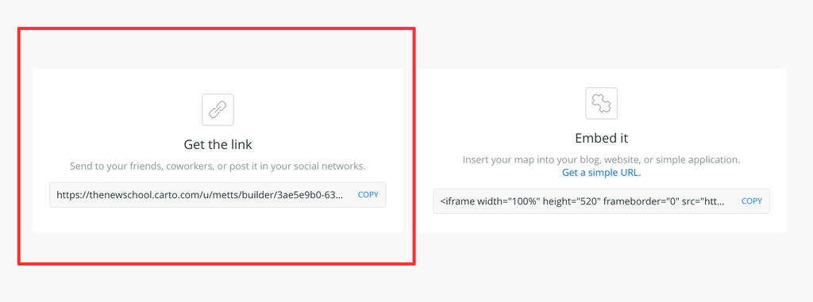

Copy `link` (left side) not `iframe embed` (right side).

[figure not shown]

Copy both `code` and `live site` links.

- Once complete, upload the PDF synopsis as a CANVAS submission for the Class 4 Assignment.